# Experimental Design and Probability

## Does biodiversity affect ecosystem function?

Cedar Creek Reserve, Minnesota

[figure not shown]

Does higher plant biodiversity affect ecosystem stability?

Tilman et al. (2006) seeded 161 plots (9 x 9m) with varying numbers of plant species (1, 2, 4, 8, 16).

Plant species were assigned randomly to plots (18 possible species).

After 10 years of maintenance and measurement, researchers measured the *stability* of plant biomass production for each plot:

\[ \begin{aligned} \text{Biomass stability} = \frac{\bar{x}_\text{biomass}}{s_\text{biomass over 10 years}} \\ \end{aligned} \]

## Load the data

```r
# Set the web address where R will look for files from this repository
repo_url <- "https://raw.githubusercontent.com/elahi/xdp/master/data/"
dat <- read_csv(paste(repo_url,
                      "chap17e3PlantDiversityAndStabilityRaw.csv",
                      sep = ""))
```

```r
summary(dat)
```

```
##     nSpecies      biomassStability
##  Min.   : 1.000   Min.   :      4
##  1st Qu.: 2.000   1st Qu.:     22
##  Median : 4.000   Median :     55
##  Mean   : 6.317   Mean   :  44678
##  3rd Qu.: 8.000   3rd Qu.:    181
##  Max.   :16.000   Max.   :6990062
```

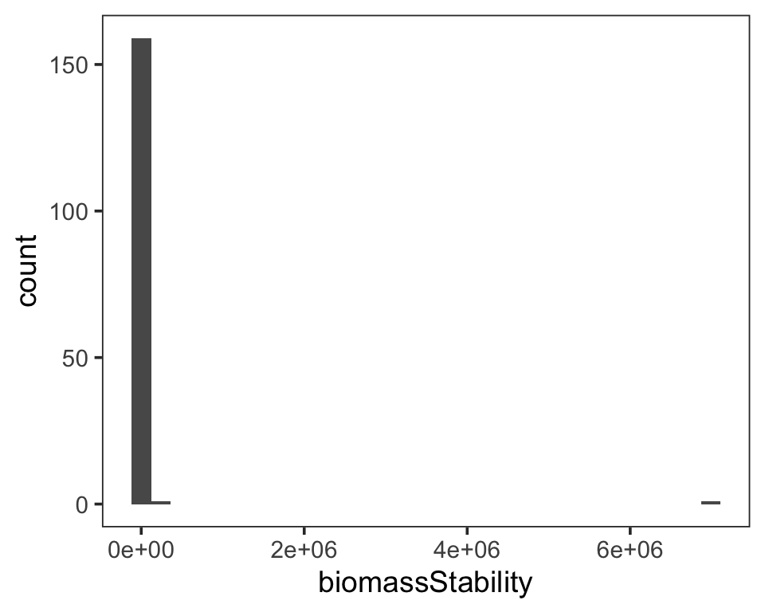

```r
dat %>% ggplot(aes(biomassStability)) +
  geom_histogram()
```

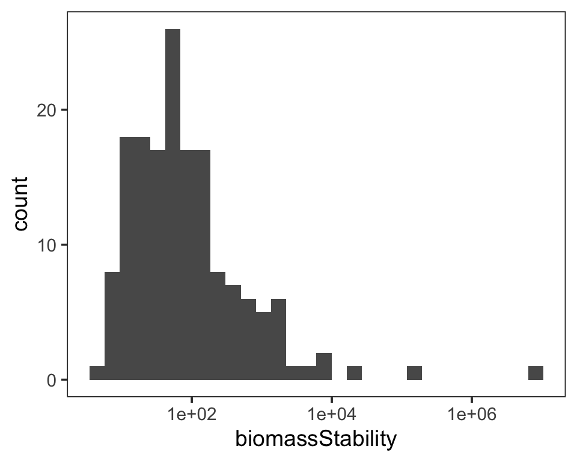

```r
dat %>% ggplot(aes(biomassStability)) +
  geom_histogram() + scale_x_log10()
```

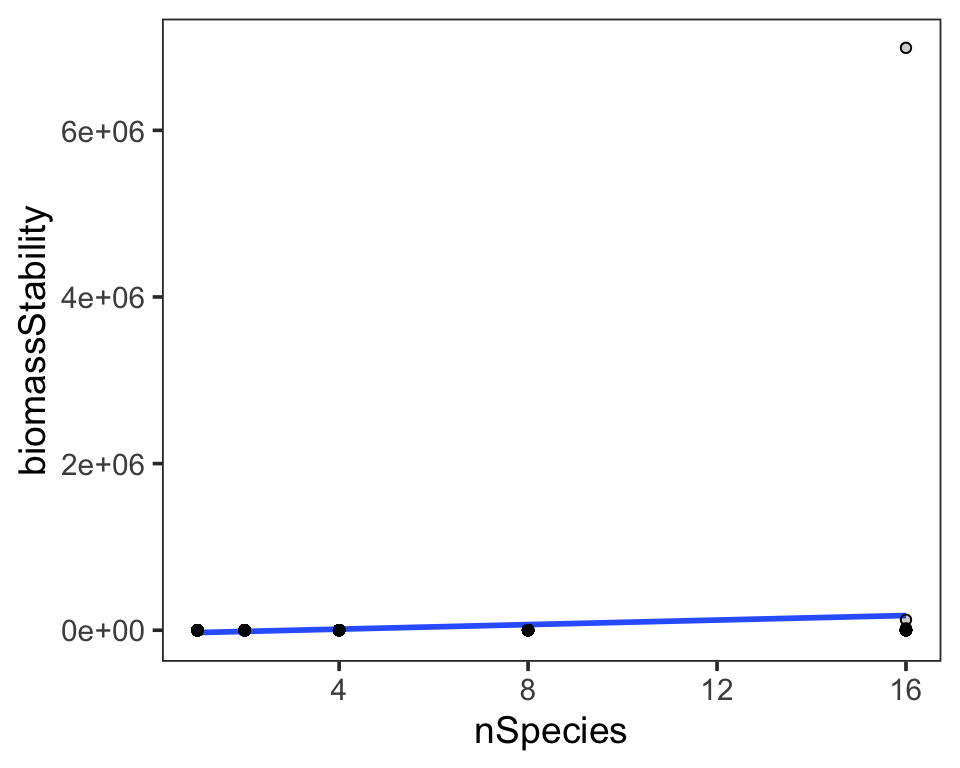

```r
dat %>% ggplot(aes(nSpecies, biomassStability)) +
  geom_smooth(method = "lm", se = FALSE) +
  geom_point(shape = 1, color = "black") +
  geom_point(shape = 19, fill = "black", alpha = 0.2)
```

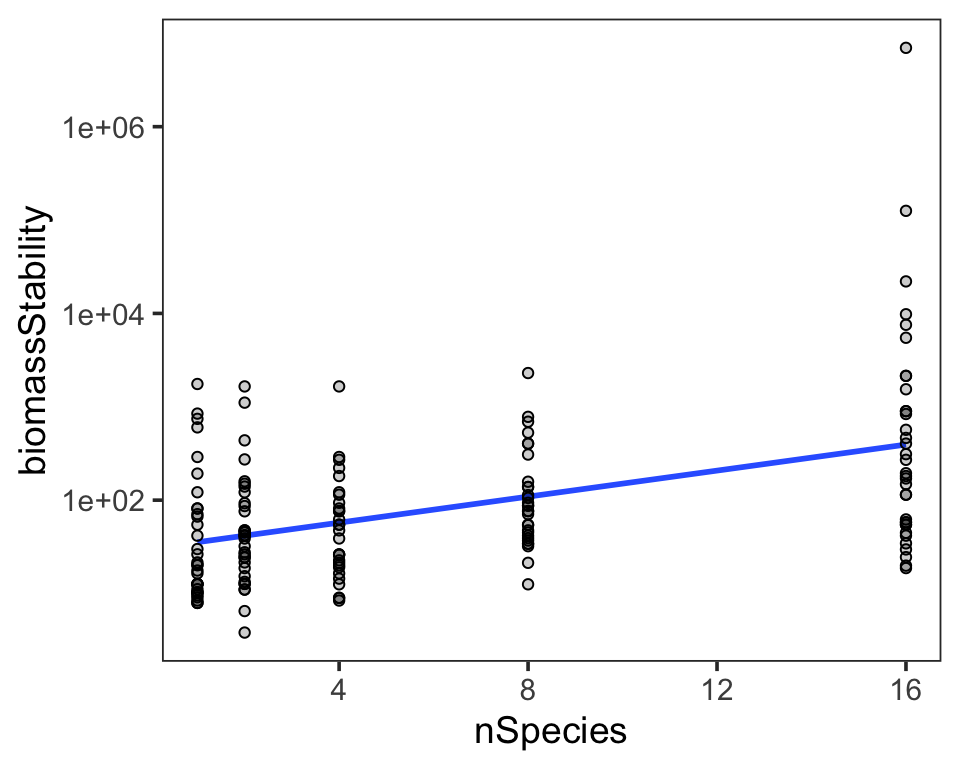

```r
dat %>% ggplot(aes(nSpecies, biomassStability)) +
  geom_smooth(method = "lm", se = FALSE) +
  geom_point(shape = 1, color = "black") +
  geom_point(shape = 19, fill = "black", alpha = 0.2) +
  scale_y_log10()
```

## Log transformation

**Transformation**: rescaling of data using a function

When observations are skewed so strongly that the details are obscured, we often apply a (natural) log transformation.

This transformation can be applied to independent or dependent variables.

Beware: can't log a negative value (add 1 or other small amount to all observations)

[figure not shown]

```r
dat <- dat %>%
  mutate(stability_log = log(biomassStability)) # natural log (base e)
dat
```

```
## # A tibble: 161 x 3
##    nSpecies biomassStability stability_log
##       <int>            <dbl>         <dbl>
##  1        1           1755.           7.47
##  2        1            846.           6.74
##  3        1            742.           6.61
##  4        1            602.           6.4
##  5        1            290.           5.67
##  6        1            192.           5.26
##  7        1            122.           4.80
##  8        1             81.5          4.40
##  9        1             81.5          4.40
## 10        1             70.8          4.26
## # … with 151 more rows
```

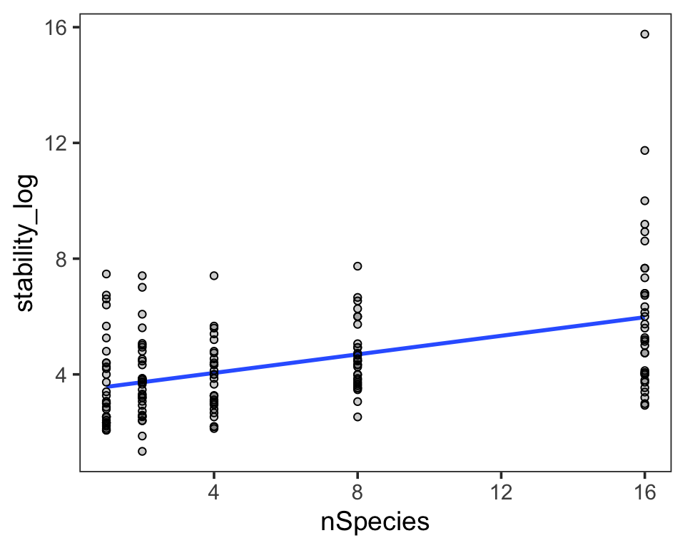

```r
dat %>% ggplot(aes(nSpecies, stability_log)) +
  geom_smooth(method = "lm", se = FALSE) +
  geom_point(shape = 1, color = "black") +
  geom_point(shape = 19, fill = "black", alpha = 0.2)
```

```r
fit1 <- lm(biomassStability ~ nSpecies, data = dat)
fit1
```

```
##
## Call:
## lm(formula = biomassStability ~ nSpecies, data = dat)
##
## Coefficients:
## (Intercept)     nSpecies
##      -41475        13639
```

```r
summary(fit1)
```

```
##
## Call:
## lm(formula = biomassStability ~ nSpecies, data = dat)
##
## Residuals:
##     Min      1Q  Median      3Q     Max
## -176726  -67593  -13025   14337 6813317
##
## Coefficients:
##             Estimate Std. Error t value Pr(>|t|)
## (Intercept)   -41475      64866  -0.639   0.5235
## nSpecies       13639       7671   1.778   0.0773 .
## ---
## Signif. codes:  0 '***' 0.001 '**' 0.01 '*' 0.05 '.' 0.1 ' ' 1
##
## Residual standard error: 547200 on 159 degrees of freedom
## Multiple R-squared:  0.0195, Adjusted R-squared:  0.01333
## F-statistic: 3.161 on 1 and 159 DF,  p-value: 0.07731
```

## Check assumptions

Linearity

- plot residuals against fitted values, should be scattered around 0

Normally distributed residuals

- plot histogram of residuals or QQ plot

Residuals display constant variance (homoscedasticity)

- plot residuals against fitted values, should be scattered around 0

Independence of residuals (i.e., observations)

- often violated in time / space / phylogeny

Plot residuals vs fitted values

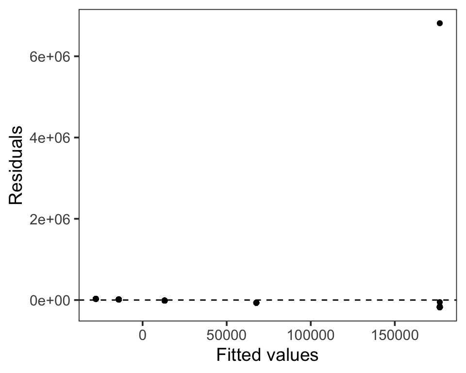

```r
ggplot(data = fit1, aes(x = .fitted, y = .resid)) +
  geom_point() +
  geom_hline(yintercept = 0, linetype = "dashed") +
  labs(x = "Fitted values", y = "Residuals")
```

Plot residuals: histogram

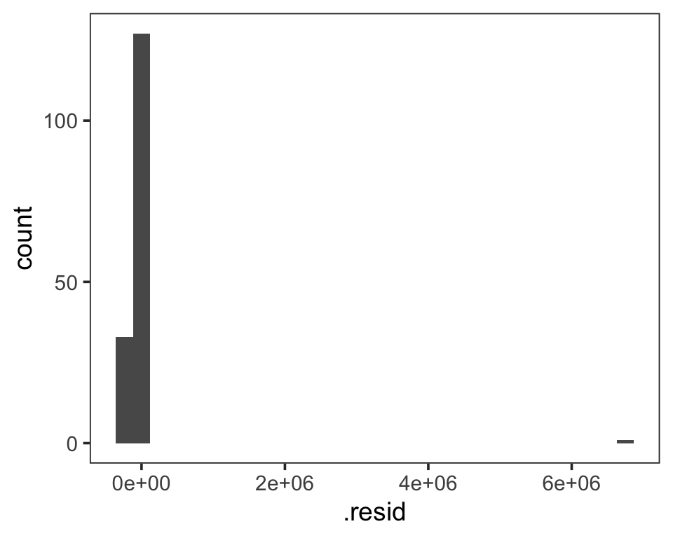

```r
ggplot(data = fit1, aes(x = .resid)) +
  geom_histogram()
```

Fit model to log-transformed data

```r
fit2 <- lm(stability_log ~ nSpecies, data = dat)
summary(fit2)
```

```
##
## Call:
## lm(formula = stability_log ~ nSpecies, data = dat)
##
## Residuals:
##     Min      1Q  Median      3Q     Max
## -3.0458 -1.1390 -0.2986  0.8010  9.7842
##
## Coefficients:
##             Estimate Std. Error t value Pr(>|t|)
## (Intercept)  3.40807    0.20509  16.617  < 2e-16 ***
## nSpecies     0.16048    0.02425   6.617 5.32e-10 ***
## ---
## Signif. codes:  0 '***' 0.001 '**' 0.01 '*' 0.05 '.' 0.1 ' ' 1
##
## Residual standard error: 1.73 on 159 degrees of freedom
## Multiple R-squared:  0.2159, Adjusted R-squared:  0.211
## F-statistic: 43.79 on 1 and 159 DF,  p-value: 5.318e-10
```

Log-transformed data

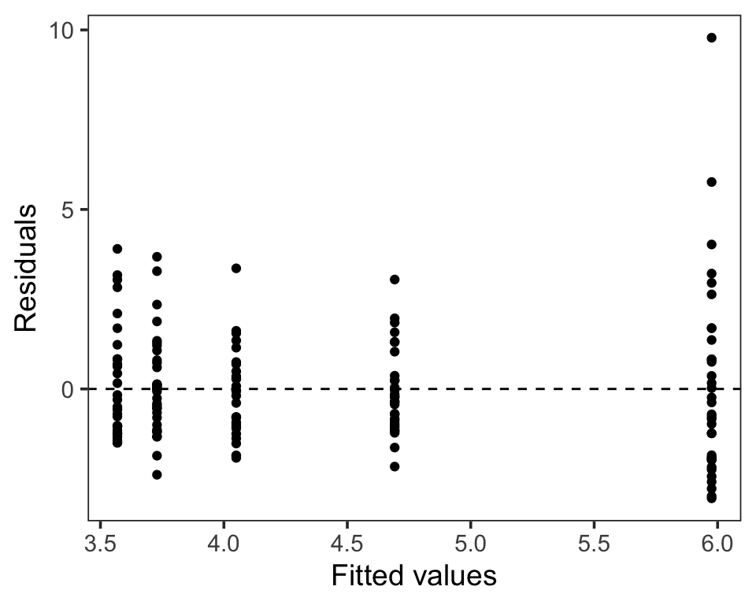

```r
ggplot(data = fit2, aes(x = .fitted, y = .resid)) +
  geom_point() +
  geom_hline(yintercept = 0, linetype = "dashed") +
  labs(x = "Fitted values", y = "Residuals")
```

Log-transformed data

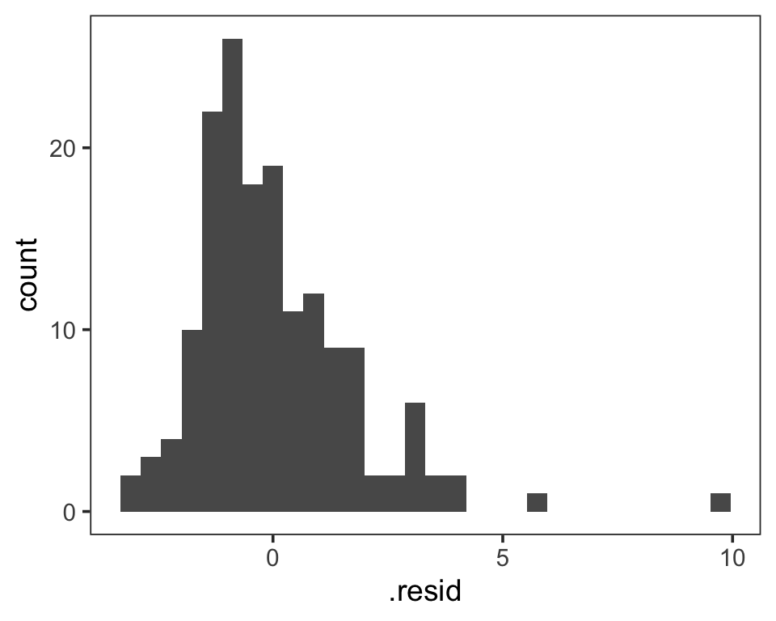

```r
ggplot(data = fit2, aes(x = .resid)) +
  geom_histogram()
```

Confidence vs prediction intervals

```r
newdata <- data.frame(nSpecies = seq(1, 16, by = 1))

df_prediction <- predict(fit2, newdata, interval = "predict") %>%
  data.frame() %>%
  mutate(nSpecies = seq(1, 16, by = 1))

df_confidence <- predict(fit2, newdata, interval = "confidence") %>%
  data.frame() %>%
  mutate(nSpecies = seq(1, 16, by = 1))
```

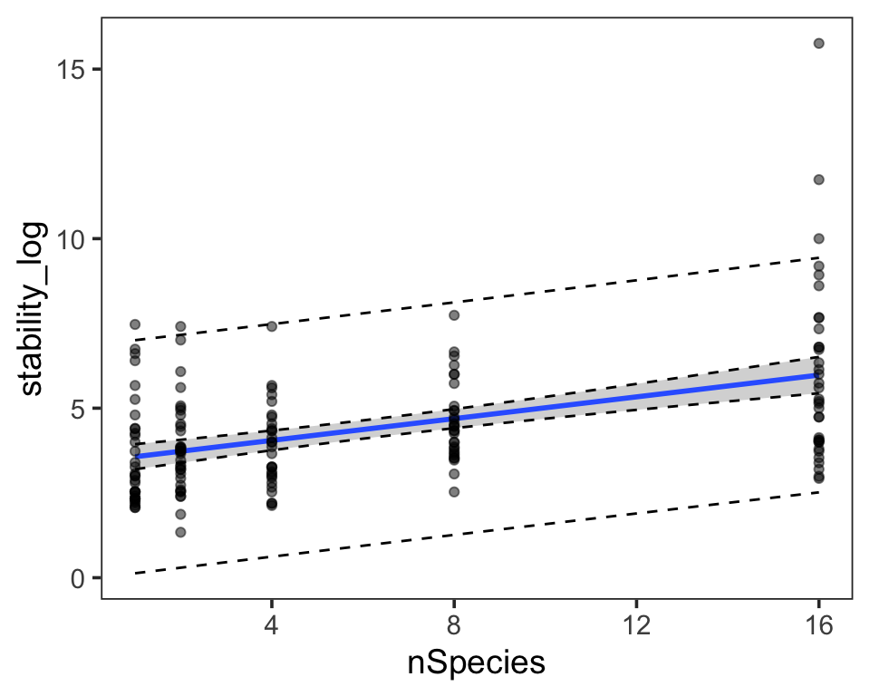

```r
dat %>%
  ggplot(aes(nSpecies, stability_log)) +
  geom_smooth(method = "lm") +
  geom_point(alpha = 0.5) +
  geom_line(data = df_prediction, aes(x = nSpecies, y = lwr),
            linetype = "dashed") +
  geom_line(data = df_prediction, aes(x = nSpecies, y = upr),
            linetype = "dashed") +
  geom_line(data = df_confidence, aes(x = nSpecies, y = lwr),
            linetype = "dashed") +
  geom_line(data = df_confidence, aes(x = nSpecies, y = upr),
            linetype = "dashed")
```

## Other transformations

For count data

- square-root transformation

For proportion data

- logit transformation
- log(p / (1-p))

## Exercise

Plot the data in a sensible way. Use planned or unplanned comparisons as appropriate.

How do your interpretations differ between the ANOVA and regression analysis?